# Data Analysis: Toronto Major Crime Indicators 2018

12/08/2019

## 1. Introduction

Toronto Police made publicly available its data on the **[“Toronto Police Service Public Safety Data Portal”](https://data.torontopolice.on.ca/search?tags=MCI)**.

We are interested in exploring the **[Major Crime Indicatiors (MCI) for 2018](https://data.torontopolice.on.ca/datasets/mci-2014-to-2018)**.

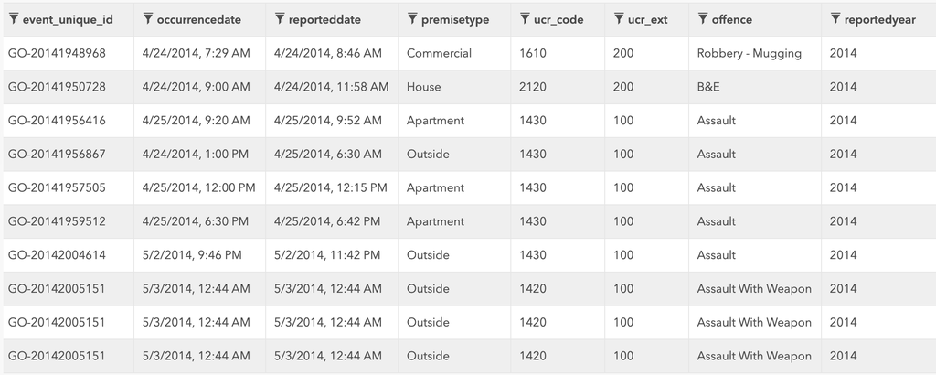

## 2. Exploratory Data Analysis

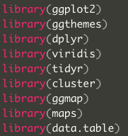

Let’s load the data:

```r
toronto = fread('./assets/MCI_2014_to_2018.csv')
```

## 3. Data Preparation (Data Munging)

What features are available?

```r
names(toronto)
```

```
##  [1] "X"                   "Y"                   "Index_"
##  [4] "event_unique_id"     "occurrencedate"      "reporteddate"
##  [7] "premisetype"         "ucr_code"            "ucr_ext"
## [10] "offence"             "reportedyear"        "reportedmonth"
## [13] "reportedday"         "reporteddayofyear"   "reporteddayofweek"
## [16] "reportedhour"        "occurrenceyear"      "occurrencemonth"
## [19] "occurrenceday"       "occurrencedayofyear" "occurrencedayofweek"
## [22] "occurrencehour"      "MCI"                 "Division"
## [25] "Hood_ID"             "Neighbourhood"       "Lat"
## [28] "Long"                "ObjectId"
```

The structure of the dataset:

```r
str(toronto)
```

```
## Classes 'data.table' and 'data.frame':   167525 obs. of  29 variables:
##  $ X                  : num  -79.3 -79.5 -79.5 -79.6 -79.5 ...
##  $ Y                  : num  43.7 43.8 43.7 43.7 43.7 ...
##  $ Index_             : int  214 215 216 217 218 219 220 221 222 223 ...
##  $ event_unique_id    : chr  "GO-20141948968" "GO-20141950728" "GO-20141956416" "GO-20141956867" ...
##  $ occurrencedate     : chr  "2014-04-24T11:29:00.000Z" "2014-04-24T13:00:00.000Z" "2014-04-25T13:20:00.000Z" "2014-04-24T17:00:00.000Z" ...
##  $ reporteddate       : chr  "2014-04-24T12:46:00.000Z" "2014-04-24T15:58:00.000Z" "2014-04-25T13:52:00.000Z" "2014-04-25T10:30:00.000Z" ...
##  $ premisetype        : chr  "Commercial" "House" "Apartment" "Outside" ...
##  $ ucr_code           : int  1610 2120 1430 1430 1430 1430 1430 1420 1420 1420 ...
##  $ ucr_ext            : int  200 200 100 100 100 100 100 100 100 100 ...
##  $ offence            : chr  "Robbery - Mugging" "B&E" "Assault" "Assault" ...
##  $ reportedyear       : int  2014 2014 2014 2014 2014 2014 2014 2014 2014 2014 ...
##  $ reportedmonth      : chr  "April" "April" "April" "April" ...
##  $ reportedday        : int  24 24 25 25 25 25 3 3 3 3 ...
##  $ reporteddayofyear  : int  114 114 115 115 115 115 123 123 123 123 ...
```

[output cut: 16 more lines]

Dimensions:

```r
dim(toronto)
```

```
## [1] 167525     29
```

Are there duplicated event ids?

```r
toronto_dupl_ids <- subset(toronto, duplicated(toronto$event_unique_id))
dim(toronto_dupl_ids)
```

```
## [1] 21708    29
```

```r
toronto_dupl_rows <- duplicated(toronto)
dim(toronto_dupl_rows)
```

[output not shown]

```r
distinct_ids <- distinct(select(toronto, event_unique_id))
dim(distinct_ids)
```

```
## [1] 145817      1
```

The dataset has 21708 duplicated event ids, - almost 13%, though no duplicate rows. Some events have the same ids but split in several offences, etc.

```r
nrow(toronto_dupl_ids) / nrow(toronto) * 100
```

```
## [1] 12.95807
```

Let’s drop the duplicates:

```r
toronto <- subset(toronto, !duplicated(toronto$event_unique_id))
dim(toronto)
```

```
## [1] 145817     29
```

In what years did the crimes occur?

```r
unique(toronto$occurrenceyear) %>% sort()
```

```
##  [1] 2000 2001 2002 2003 2004 2005 2006 2007 2008 2009 2010 2011 2012 2013
## [15] 2014 2015 2016 2017 2018
```

When were the crimes reported?

```r
unique(toronto$reportedyear) %>% sort()
```

```
## [1] 2014 2015 2016 2017 2018
```

Let’s have a look at how many crimes were reported for each year.

```r
toronto %>% group_by(occurrenceyear) %>% summarise(n=n())
```

```
## # A tibble: 20 x 2
##    occurrenceyear     n
##             <int> <int>
##  1           2000    13
##  2           2001    10
##  3           2002     7
##  4           2003     8
##  5           2004     9
##  6           2005     8
##  7           2006     7
##  8           2007    16
##  9           2008    23
## 10           2009    28
## 11           2010    49
## 12           2011    66
## 13           2012   117
## 14           2013   452
## 15           2014 27829
## 16           2015 28045
## 17           2016 28274
## 18           2017 29746
## 19           2018 31070
## 20             NA    40
```

The amount of crimes reported in the years 2014-2018 is exceeding the prior years by the order of magnitude. Let’s work with 2014-2018 crimes only, and remove prior years’ data.

```r
toronto <- toronto[toronto$occurrenceyear == 2014 | toronto$occurrenceyear == 2015 | toronto$occurrenceyear == 2016 | toronto$occurrenceyear == 2017 | toronto$occurrenceyear == 2018,]
toronto %>% group_by(occurrenceyear) %>% summarise(n=n())
```

```
## # A tibble: 5 x 2
##   occurrenceyear     n
##            <int> <int>
## 1           2014 27829
## 2           2015 28045
## 3           2016 28274
## 4           2017 29746
## 5           2018 31070
```

```r
dim(toronto)
```

```
## [1] 144964     29
```

Let’s keep only the columns that we need.

```r
keep <- c("event_unique_id", "occurrencedate", "premisetype", "offence", "occurrenceyear", "occurrencemonth", "occurrenceday", "occurrencedayofweek", "occurrencehour", "MCI", "Neighbourhood", "Lat", "Long")
toronto <- subset(toronto, select = keep)
str(toronto)
```

```
## Classes 'data.table' and 'data.frame':   144964 obs. of  13 variables:
##  $ event_unique_id    : chr  "GO-20141948968" "GO-20141950728" "GO-20141956416" "GO-20141956867" ...
##  $ occurrencedate     : chr  "2014-04-24T11:29:00.000Z" "2014-04-24T13:00:00.000Z" "2014-04-25T13:20:00.000Z" "2014-04-24T17:00:00.000Z" ...
##  $ premisetype        : chr  "Commercial" "House" "Apartment" "Outside" ...
##  $ offence            : chr  "Robbery - Mugging" "B&E" "Assault" "Assault" ...
##  $ occurrenceyear     : int  2014 2014 2014 2014 2014 2014 2014 2014 2014 2014 ...
##  $ occurrencemonth    : chr  "April" "April" "April" "April" ...
##  $ occurrenceday      : int  24 24 25 24 25 25 3 3 7 7 ...
##  $ occurrencedayofweek: chr  "Thursday" "Thursday" "Friday" "Thursday" ...
##  $ occurrencehour     : int  11 13 13 17 16 22 1 4 11 15 ...
##  $ MCI                : chr  "Robbery" "Break and Enter" "Assault" "Assault" ...
##  $ Neighbourhood      : chr  "North Riverdale (68)" "Black Creek (24)" "Brookhaven-Amesbury (30)" "Rexdale-Kipling (4)" ...
##  $ Lat                : num  43.7 43.8 43.7 43.7 43.7 ...
##  $ Long               : num  -79.3 -79.5 -79.5 -79.6 -79.5 ...
##  - attr(*, ".internal.selfref")=<externalptr>
```

## 4. Data Exploration

### To do: the same as below, but for each of the 5 years: 2014 to 2018

The majority of crimes is “Assault”:

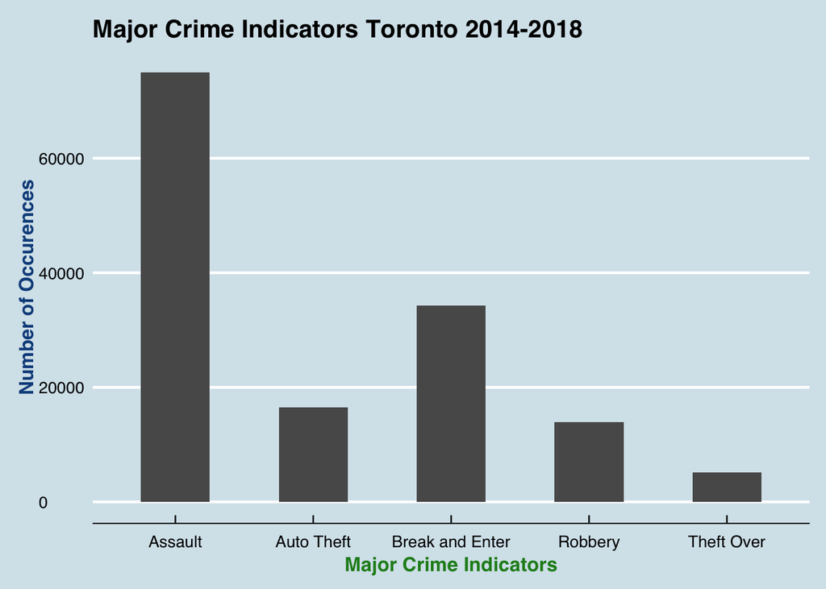

```r
# Here, geom_bar(stat="bin") by default, counting cases in each group of MCI
ggplot(toronto, aes(x = MCI)) +
  geom_bar(width = 0.5) +
  labs(title = "Major Crime Indicators Toronto 2014-2018",
       x="Major Crime Indicators",
       y="Number of Occurences") +
  theme_economist() +
  theme(
    axis.title = element_text(size = 12, face = "bold"),
    axis.title.x = element_text(color="forestgreen", vjust=-0.35),
    axis.title.y = element_text(color="dodgerblue4" , vjust=0.35)
    )
```

### What were the major crimes in Toronto in 2014-2018, overall?

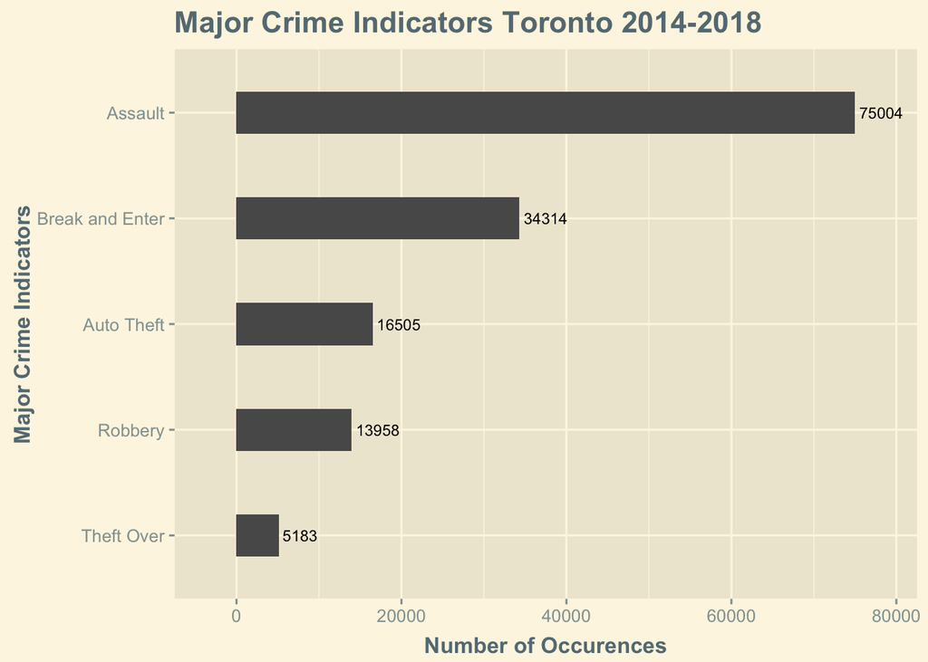

```r
# To be able to reorder MCI data inside MCI, we need to create a separate n (count) column;
# "crime" is a (5,2) dataframe with "MCI" and "n" columns.
crime <- toronto %>% group_by(MCI) %>% summarise(n=n())
#crime <- crime[order(crime$n, decreasing = TRUE),]
ggplot(data = crime,
       aes(x = reorder(MCI, n), y = n)) +
  # Here, geom_bar(stat="identity") instructs to represent values
  # already counted (mapped to "y = n" in aesthetics)
  geom_bar(stat = 'identity',
           width = 0.4) +
  geom_text(aes(label = n),
            hjust = -0.1,
            size = 3) +
  # to prevent labels to be cut off
  scale_y_continuous(expand = c(.1, .1)) +
  coord_flip() +
  labs(title = "Major Crime Indicators Toronto 2014-2018",
       x="Major Crime Indicators",
       y="Number of Occurences") +
  theme_solarized_2() +
  theme(
    plot.title = element_text(size = 16, face = "bold"),
    axis.title = element_text(size = 12, face = "bold"),
    axis.title.x = element_text(vjust=-0.35),
    axis.title.y = element_text(vjust=0.35)
    )
```

### What were the different assault types? Which one is the worst?

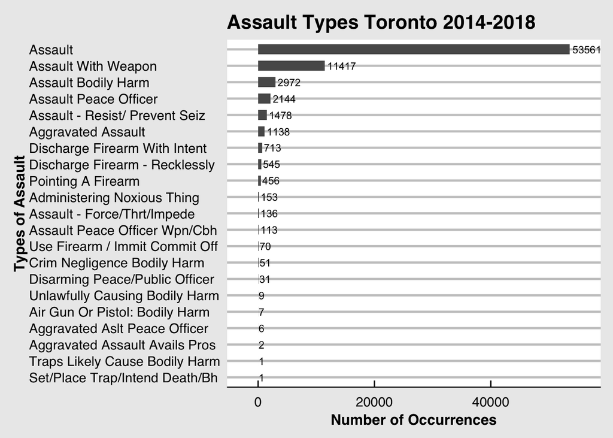

```r
# Grouping inside a subset of dataframe: only those observations that have "Assault" in MCI column
assault_by_offence <- toronto[toronto$MCI == 'Assault', ] %>% group_by(offence) %>% summarise(n=n())
#assault_by_offence <- assault_by_offence[order(assault_by_offence$n, decreasing = TRUE), ]
ggplot(data = assault_by_offence,
       aes(x = reorder(offence, n), y = n)) +
  geom_bar(stat = 'identity',
           width = 0.6) +
  geom_text(aes(label = n),
            hjust = -0.1,
            size = 3) +
  # to prevent labels to be cut off
  scale_y_continuous(expand = c(.1, .1)) +
  coord_flip() +
  labs(x = "Types of Assault",
       y = "Number of Occurrences",
       title = "Assault Types Toronto 2014-2018") +
  theme_economist_white() +
  theme(
    plot.title = element_text(size = 16, face = "bold"),
    axis.title = element_text(size = 12, face = "bold"),
    axis.title.x = element_text(vjust=-0.4),
    axis.title.y = element_text(vjust=0.4)
    )
```

### The top offences

What are other offences, in addition to assault?

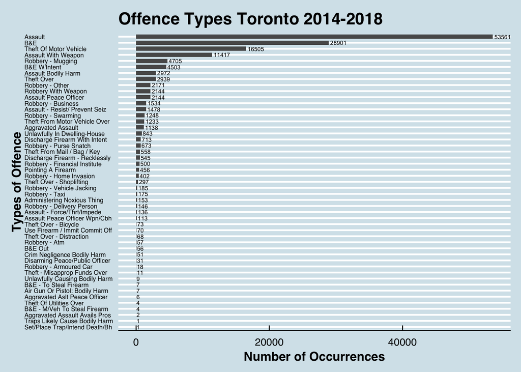

```r
crime_by_offence <- toronto %>% group_by(offence) %>%  summarise(n = n())
# Reordering inside aes() does the same job with dataframe (it would be needed for top N)
#crime_by_offence <- crime_by_offence[order(crime_by_offence$n, decreasing = TRUE), ]
ggplot(data = crime_by_offence,
       aes(x = reorder(offence, n), y = n)) +
  geom_bar(stat = 'identity',
           width = 0.7) +
  geom_text(aes(label = n),
            hjust = -0.1,
            size = 2) +
  coord_flip() +
  labs(x = "Types of Offence",
       y = "Number of Occurrences",
       title = "Offence Types Toronto 2014-2018") +
  theme_economist() +
  theme(
    plot.title = element_text(size = 16, face = "bold"),
    axis.title = element_text(size = 12, face = "bold"),
    axis.text.y = element_text(size = 6),
    axis.title.x = element_text(vjust=-0.4),
    axis.title.y = element_text(vjust=0.4)
    )
```

The second highest number of offences was: - robbery - mugging - breaking and entering with intent - assault wiht bodily harm - theft over

The third prominent group of offences: - robbery - other - robbery with weapon - assault peace officer

### Total crimes by the hour of the day

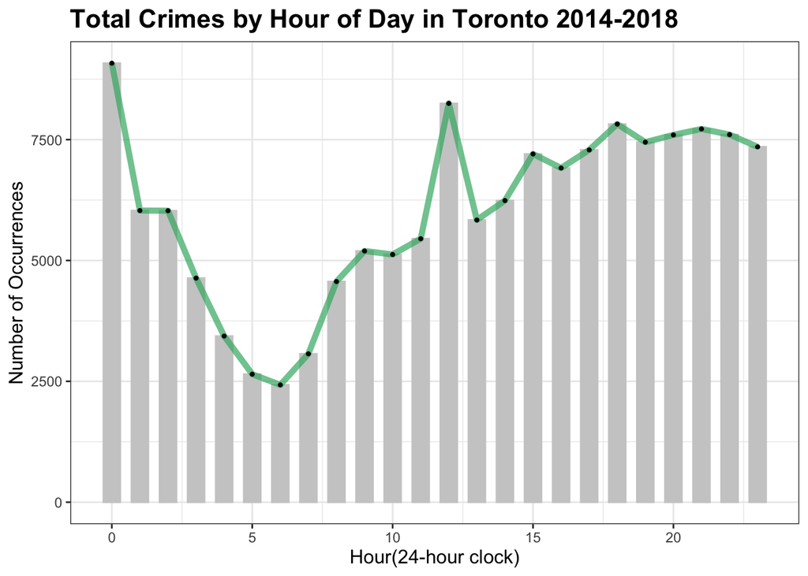

```r
crime_hour <- toronto %>%  group_by(occurrencehour) %>% summarise(n=n())

ggplot(data = crime_hour, aes(x=occurrencehour, y=n)) +
  geom_bar(stat = 'identity',
           width = 0.6,
           color = "gray80",
           fill = "gray80") +
  geom_line(size = 1.8,
            alpha = 0.7,
            color = "mediumseagreen") +
  geom_point(size = 0.8) +
  labs( x= 'Hour(24-hour clock)',
        y = 'Number of Occurrences',
        title = 'Total Crimes by Hour of Day in Toronto 2014-2018') +
  theme_bw() +
  theme(plot.title = element_text(size = 16, face = "bold"),
        axis.title = element_text(size = 12))
```

The worst hour is around midnight, another peak time is around noon, followed by around 8pm.

### Crime types by each hour of the day

```r
# grouping by two features
hour.crime <- toronto %>% group_by(occurrencehour, MCI) %>% summarise(n = n())
head(hour.crime)
```

```
## # A tibble: 6 x 3
## # Groups:   occurrencehour [2]
##   occurrencehour MCI                 n
##            <int> <chr>           <int>
## 1              0 Assault          4479
## 2              0 Auto Theft       1042
## 3              0 Break and Enter  2279
## 4              0 Robbery           764
## 5              0 Theft Over        517
## 6              1 Assault          3345
```

While assaults are the most common crimes throughout the day, they happened more frequently at noon, and then from late afternoons and until after midnight. Break and enter crimes happened more often in the mornings and at around the midnight (when no one was at home or in the office) . Robberies and auto thefts were more likely to happen in the late evenings. All of these patterns make sense.

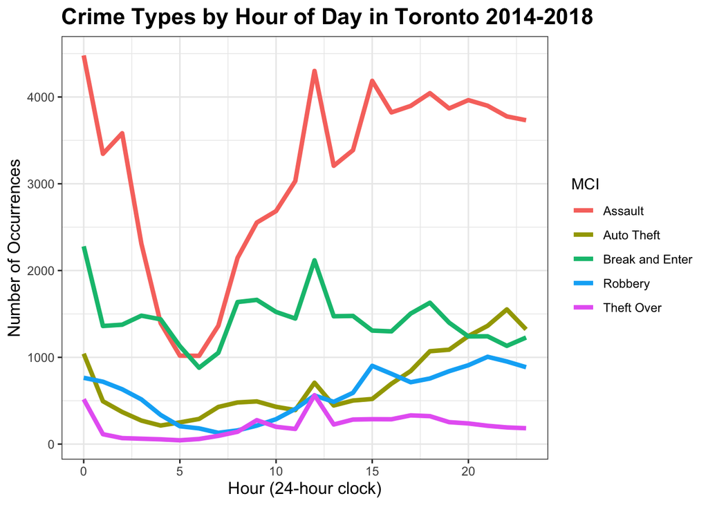

```r
ggplot(data = hour.crime,
       aes(x = occurrencehour,
           y = n,
           color = MCI)) +
  geom_line(size = 1.5) +
  labs( x= 'Hour (24-hour clock)',
        y = 'Number of Occurrences',
        title = 'Crime Types by Hour of Day in Toronto 2014-2018') +
  theme_bw() +
  theme(plot.title = element_text(size = 16, face = "bold"),
        axis.title = element_text(size = 12))
```

### Crimes evolution over 5 years 2014-2018

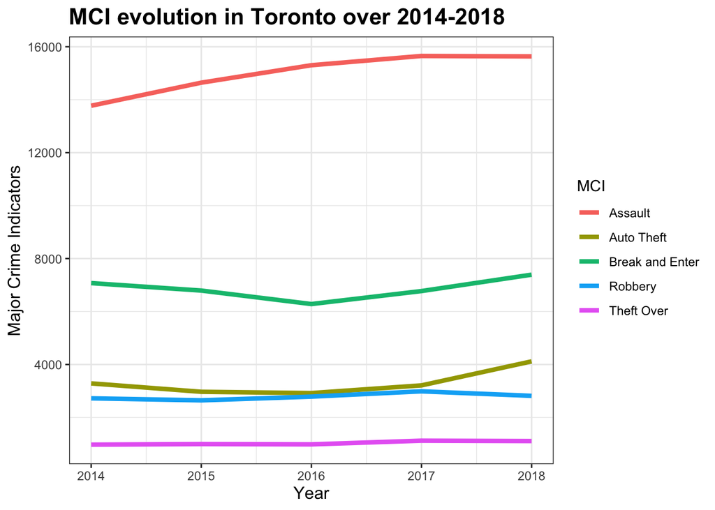

```r
year.crime <- toronto %>% group_by(occurrenceyear, MCI) %>% summarise(n = n())

ggplot(data = year.crime,
       aes(x = occurrenceyear,
           y = n,
           color = MCI)) +
  geom_line(size = 1.5) +
  #facet_grid(occurrenceyear ~ .) +
  labs( x= 'Year',
        y = 'Major Crime Indicators',
        title = 'MCI evolution in Toronto over 2014-2018') +
  theme_bw() +
  theme(plot.title = element_text(size = 16, face = "bold"),
        axis.title = element_text(size = 12))
```

### Neighbourhoods with the highest amount of crime

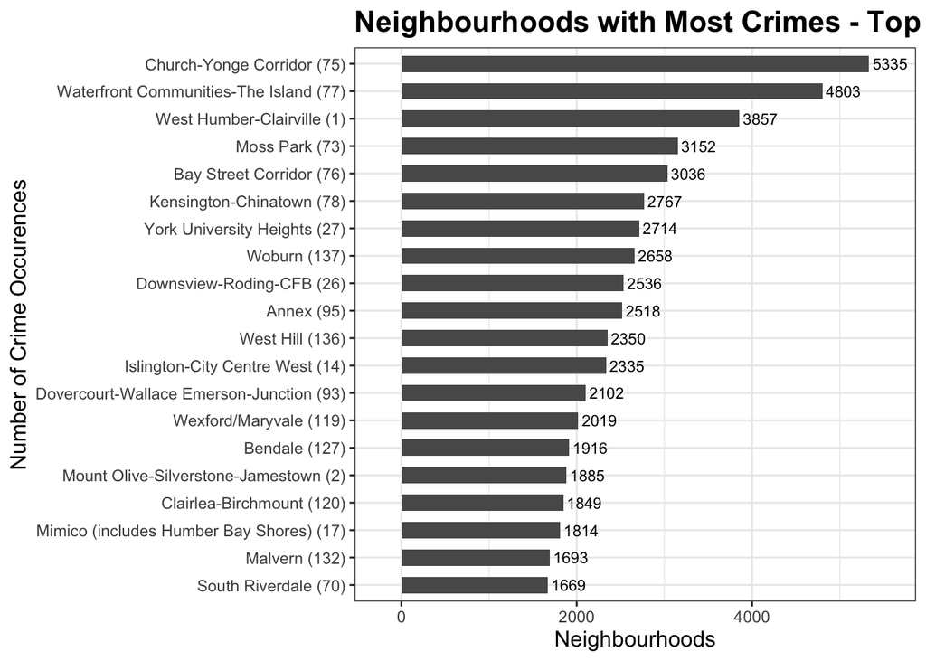

```r
crime_by_location <- toronto %>% group_by(Neighbourhood) %>%  summarise(n=n())
crime_by_location <- crime_by_location[order(crime_by_location$n, decreasing = TRUE), ]
# Since we are taking 20 top resuts, ordering (above) is important
crime_by_location_top20 <- head(crime_by_location, 20)

ggplot(data = crime_by_location_top20,
      aes(x = reorder(Neighbourhood, n), y = n)
      ) +
  geom_bar(stat = 'identity', width = 0.6) +
  geom_text(aes(label = n), hjust = -0.1, size = 3) +
  scale_y_continuous(expand = c(.1, .1)) +
  coord_flip() +
  labs( x= 'Number of Crime Occurences',
        y = 'Neighbourhoods',
        title = 'Neighbourhoods with Most Crimes - Top 20') +
  theme_bw() +
  theme(plot.title = element_text(size = 16, face = "bold"),
        axis.title = element_text(size = 12))
```

### Safest neighbourhoods

```r
tail(crime_by_location, 10)
```

```
## # A tibble: 10 x 2
##    Neighbourhood                           n
##    <chr>                               <int>
##  1 Forest Hill South (101)               343
##  2 Princess-Rosethorn (10)               343
##  3 Yonge-Eglinton (100)                  285
##  4 Markland Wood (12)                    280
##  5 Caledonia-Fairbank (109)              263
##  6 Broadview North (57)                  260
##  7 Centennial Scarborough (133)          257
##  8 Yonge-St.Clair (97)                   209
##  9 Lambton Baby Point (114)              161
## 10 Eringate-Centennial_West Deane (11)    23
```

### Top offence types in neighbourhoods

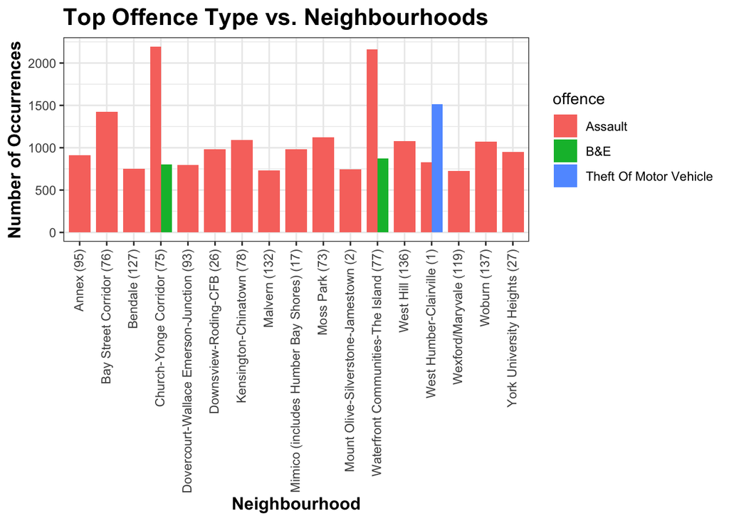

```r
offence_by_location <- toronto %>% group_by(Neighbourhood, offence) %>% summarise(n=n())
offence_by_location <- offence_by_location[order(offence_by_location$n, decreasing = T),]
offence_by_location_top20 <- head(offence_by_location, 20)

ggplot(data = offence_by_location_top20, aes(x = Neighbourhood, y = n, fill = offence)) +
  geom_bar(stat='identity', width = 0.8, position = position_dodge()) +
  labs( x= 'Neighbourhood',
        y = 'Number of Occurrences',
        title = 'Top Offence Type vs. Neighbourhoods') +
  theme_bw() +
  theme(plot.title = element_text(size = 16, face = "bold"),
        axis.title = element_text(size = 12, face = "bold"),
        axis.text.x = element_text(angle = 90, hjust = 1, vjust = .4)
        )
```

### MCI by month

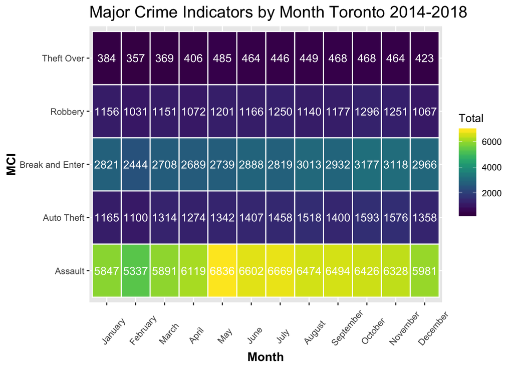

```r
crime_count <- toronto %>% group_by(occurrencemonth, MCI) %>% summarise(Total = n())
crime_count$occurrencemonth <- ordered(crime_count$occurrencemonth, levels = c('January', 'February', 'March', 'April', 'May', 'June', 'July', 'August', 'September', 'October', 'November', 'December'))

ggplot(crime_count, aes(occurrencemonth, MCI, fill = Total)) +
  geom_tile(size = 0.5, color = "white") +
  scale_fill_viridis()  +
  geom_text(aes(label=Total), color = "white") +
  labs( x= 'Month',
        y = 'MCI',
        title = 'Major Crime Indicators by Month Toronto 2014-2018') +
  theme(plot.title = element_text(size = 16),
        axis.title = element_text(size = 12, face = "bold"),
        axis.text.x = element_text(angle = 50, hjust = .1, vjust = .1),
        axis.title.x = element_text(vjust = -0.1),
        axis.title.y = element_text(vjust = 0.6)
        )
```

### MCI by day of the week

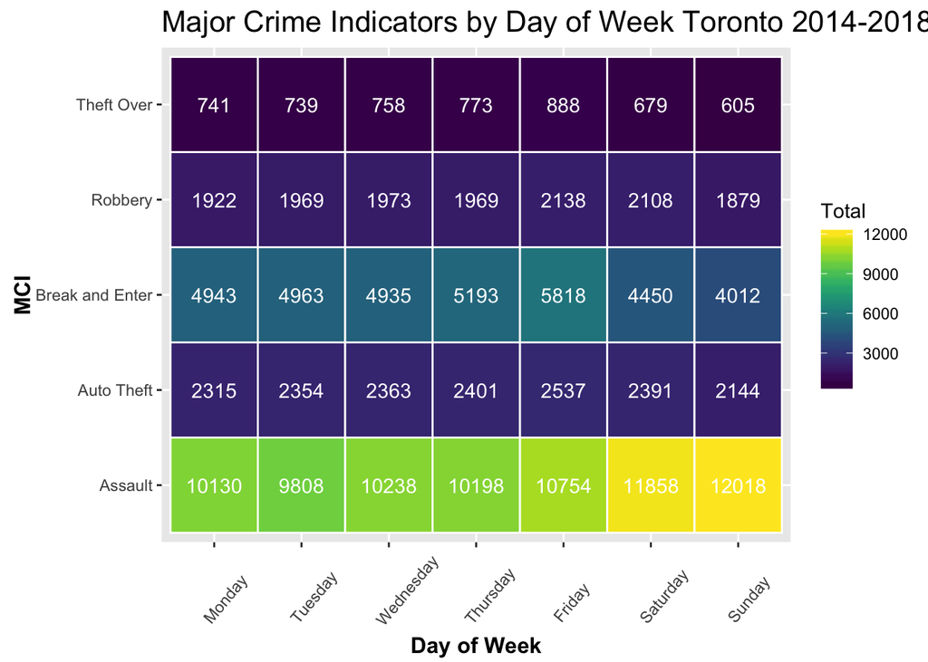

```r
crime_count <- toronto %>% group_by(occurrencedayofweek, MCI) %>% summarise(Total = n())
crime_count$occurrencedayofweek <- ordered(crime_count$occurrencedayofweek, levels = c('Monday', 'Tuesday', 'Wednesday', 'Thursday', 'Friday', 'Saturday', 'Sunday'))

ggplot(crime_count, aes(occurrencedayofweek, MCI, fill = Total)) +
  geom_tile(size = 0.5, color = "white") +
  scale_fill_viridis()  +
  geom_text(aes(label=Total), color = "white") +
  labs( x= 'Day of Week',
        y = 'MCI',
        title = 'Major Crime Indicators by Day of Week Toronto 2014-2018') +
  theme(plot.title = element_text(size = 16),
        axis.title = element_text(size = 12, face = "bold"),
        axis.text.x = element_text(angle = 50, hjust = 0.1, vjust = .1),
        axis.title.x = element_text(vjust = -0.1),
        axis.title.y = element_text(vjust = 0.1)
        )
```

### Todo: Seasonal crime patterns (temperature change, daylight hours, beginning and end school year)

### Todo: Homicides

## 4. K-means clustering

The goal is to create clusters of neighbourhoods with similar crime level.

```r
groups <- toronto %>% group_by(Neighbourhood, MCI) %>% summarise(n=n())
groups_wide <- spread(groups, key = MCI, value = n)
groups_wide
```

```
## # A tibble: 141 x 6
## # Groups:   Neighbourhood [141]
##    Neighbourhood Assault `Auto Theft` `Break and Ente… Robbery `Theft Over`
##    <chr>           <int>        <int>            <int>   <int>        <int>
##  1 Agincourt No…     325          125              289     130           26
##  2 Agincourt So…     479          144              378     101           62
##  3 Alderwood (2…     148           71              124      31           33
##  4 Annex (95)       1245          107              771     232          163
##  5 Banbury-Don …     344           77              338      41           41
##  6 Bathurst Man…     354          168              240      62           50
##  7 Bay Street C…    2027           95              523     215          176
##  8 Bayview Vill…     341           79              213      32           40
##  9 Bayview Wood…     153           54              154      17           10
## 10 Bedford Park…     223          186              506      58           52
## # … with 131 more rows
```

Remove categorical data (the first column)

```r
zz <- groups_wide[, -c(1,1)]
# assure no missing values
zz <- zz[complete.cases(zz),]
```